# Лабораторная работа № 15

Управление логическими томами

Павличенко Родион Андреевич

1132246838@pfur.ru

Российский университет дружбы народов

# Информация

## Докладчик

- Павличенко Родион Андреевич
- Cтудент
- Группа НПИбд-02-24
- Российский университет дружбы народов им. П. Лумумбы
- 1132246838@pfur.ru

# Цель работы

## Цель лабораторной работы

- Получить навыки управления логическими томами (LVM)
- Освоить создание и управление физическими томами, группами томов и логическими томами
- Изучить операции расширения и уменьшения томов

# Выполнение лабораторной работы

## Подготовка к работе с LVM

Удаление строк автомонтирования из /etc/fstab для подготовки дисков к работе с LVM

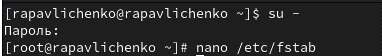

## Редактирование файла fstab

Удаление записей о монтировании /mnt/data и /mnt/data-ext для освобождения дисков

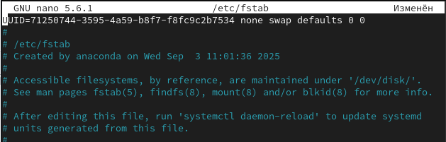

## Отмонтирование разделов

Проверка отмонтирования дисков /dev/sdb и /dev/sdc перед созданием LVM

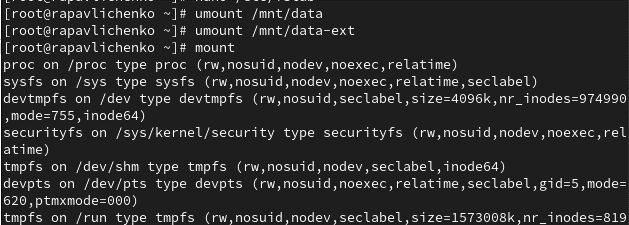

## Очистка существующей разметки

Удаление всех существующих разделов на диске /dev/sdb с помощью fdisk

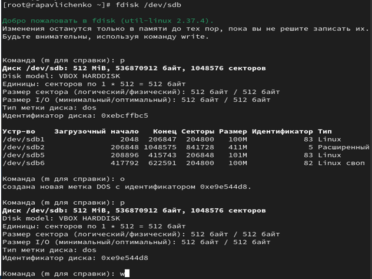

## Обновление таблицы разделов

Применение изменений разметки с помощью partprobe и проверка результата

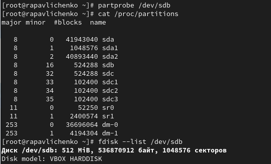

## Создание раздела для LVM

Создание основного раздела размером 100 МБ для использования в LVM

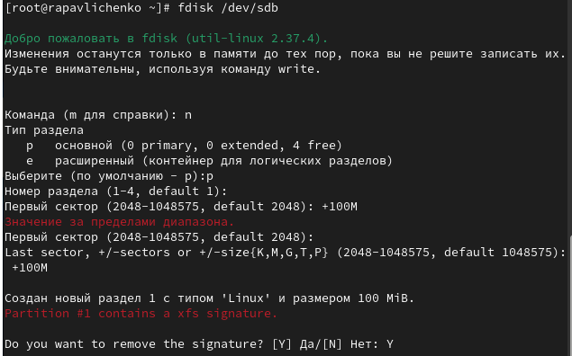

## Изменение типа раздела на LVM

Установка типа раздела 8e (Linux LVM) для подготовки к работе с логическими томами

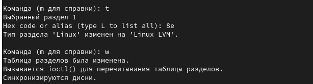

## Создание физического тома

Инициализация раздела как физического тома LVM и проверка создания

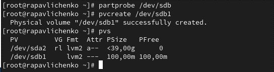

## Создание группы томов

Объединение физических томов в группу томов vgdata и проверка результата

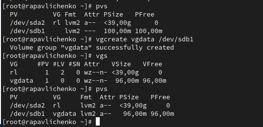

## Создание логического тома

Создание логического тома lvdata размером 50% от доступного пространства

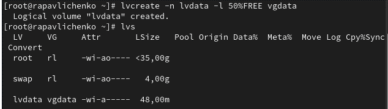

## Форматирование логического тома

Создание файловой системы ext4 на логическом томе и точки монтирования

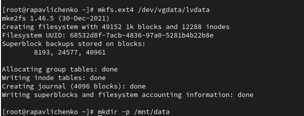

## Настройка автоматического монтирования

Добавление записи в /etc/fstab для автоматического монтирования при загрузке

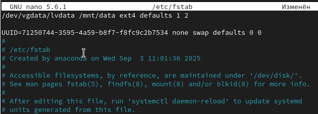

## Проверка монтирования

Тестирование автоматического монтирования с помощью mount -a

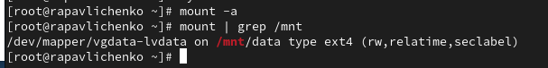

## Добавление второго раздела LVM

Создание дополнительного раздела на диске для расширения LVM

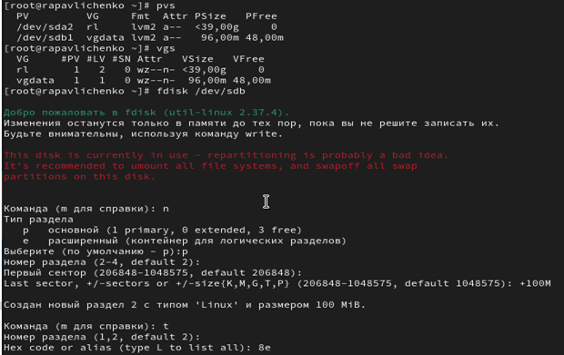

## Расширение группы томов

Добавление нового физического тома в существующую группу томов vgdata

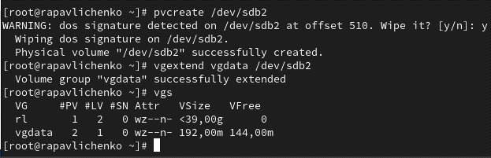

## Проверка текущих размеров

Анализ размеров логического тома и файловой системы перед расширением

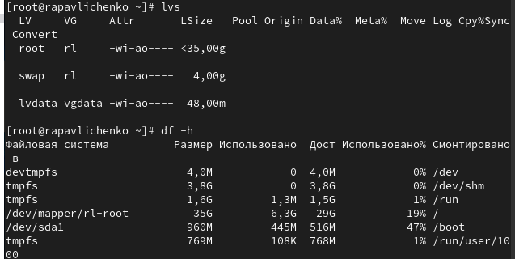

## Расширение логического тома

Увеличение размера lvdata на 50% от свободного пространства с resize файловой системы

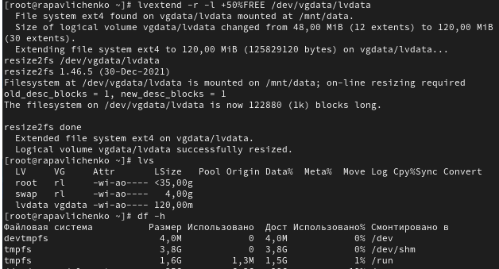

## Уменьшение логического тома

Сокращение размера логического тома на 50 МБ для демонстрации гибкости LVM

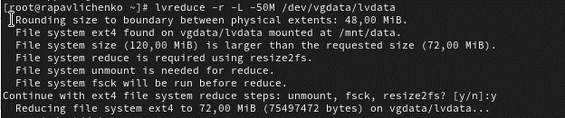

## Проверка изменения размера

Подтверждение успешного изменения размера логического тома

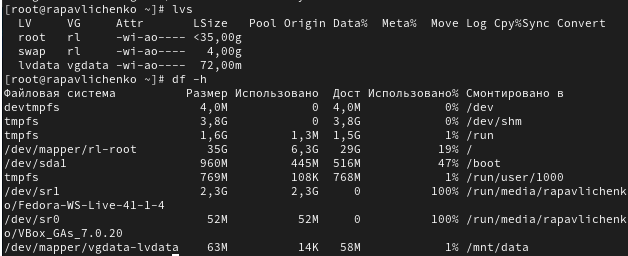

# Самостоятельная работа

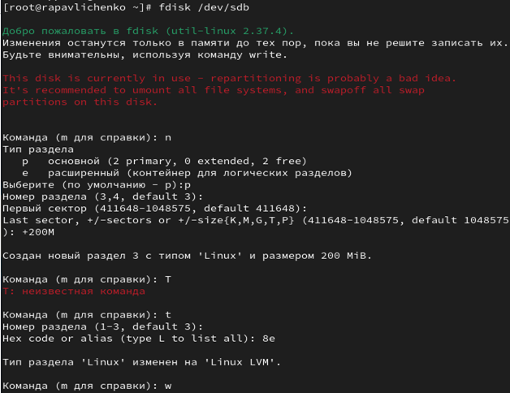

## Обновление разметки диска

Применение изменений разметки и проверка созданных разделов

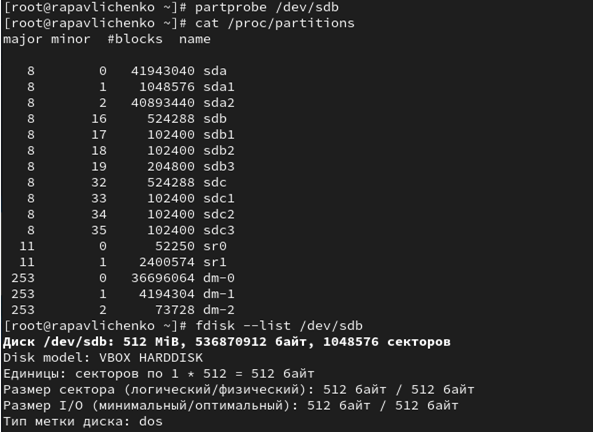

## Создание физического тома и группы томов

Инициализация физического тома и создание группы томов vggroups

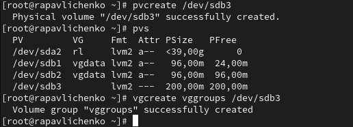

## Создание логического тома lvgroup

Формирование логического тома в группе vggroups и проверка его создания

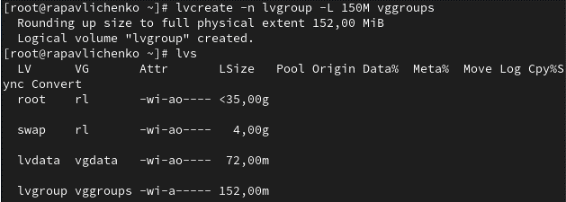

## Форматирование в XFS и создание точки монтирования

Создание файловой системы XFS на логическом томе и подготовка точки монтирования

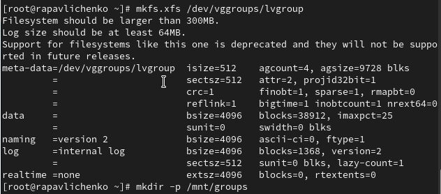

## Настройка автоматического монтирования

Добавление записи в fstab для постоянного монтирования /mnt/groups

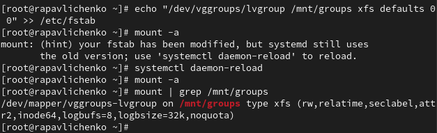

## Перезагрузка системы

Проверка устойчивости конфигурации после перезагрузки

## Проверка после перезагрузки

Убеждение в корректном монтировании логических томов после перезагрузки

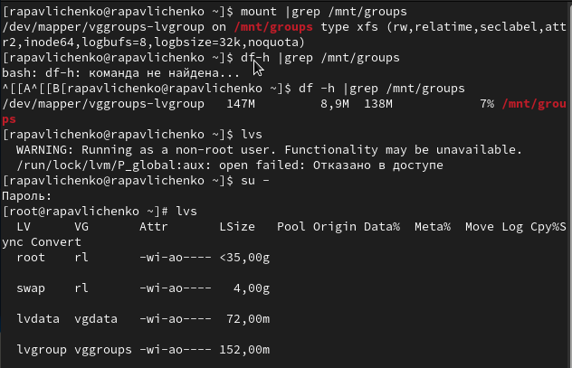

## Расширение LVM-инфраструктуры

Создание дополнительного раздела LVM на том же диске для расширения возможностей

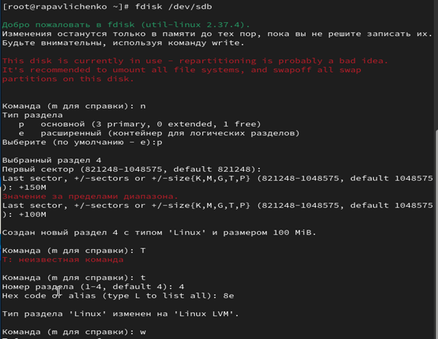

## Расширение группы томов

Добавление нового физического тома в существующую группу томов vggroups

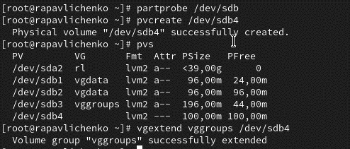

## Анализ доступного пространства

Проверка увеличения размера группы томов и текущих размеров логических томов

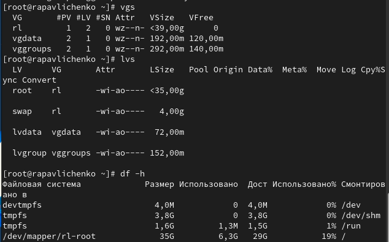

## Расширение логического тома lvgroup

Увеличение размера логического тома с использованием дополнительного пространства

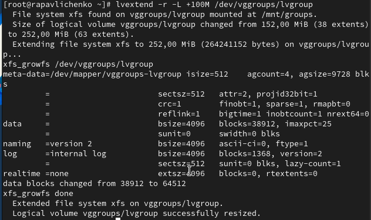

## Проверка расширения тома

Подтверждение успешного расширения логического тома и файловой системы

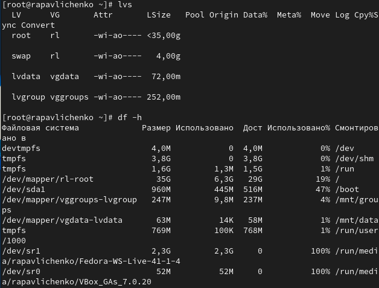

## Итоговая проверка конфигурации

Комплексная проверка всей LVM-инфраструктуры и монтирования файловых систем

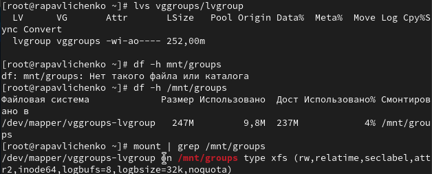

# Выводы

## Итоги работы

- Освоены основные принципы работы с Logical Volume Manager (LVM)
- Получены практические навыки создания и управления физическими томами, группами томов и логическими томами
- Изучены операции динамического расширения и уменьшения логических томов
- Приобретен опыт настройки автоматического монтирования LVM-томов
- Освоена работа с различными файловыми системами (ext4, XFS) на логических томах
- Получены навыки мониторинга и управления LVM-инфраструктурой